# Estudios de Informática, Multimedia y Telecomunicaciones

# Tipología y ciclo de vida de los datos: PRA2

Autor: Andrés Ardila, Alvaro Ortiz

diciembre 2021

# 1 Análisis de datos

## 1.1 Carga del archivo

```r
# Se establece una semilla para hacer repetible el proceso
set.seed(123)
setwd("/")

# Carga del archivo
# Se carga el juego de datos, nótese "strip.white" = TRUE para eliminar los espacios en blanco al inicio y final.
df_train <- read.csv('/run/media/vv/DatosVv/Sync/Docs/U/UOC/2/TipologiaCicloVidaDatos/PRA2/dataset/train_summarized.csv', stringsAsFactors = FALSE, strip.white = TRUE, sep = ",")
```

## 1.2 Selección de los grupos de datos que se quieren analizar/comparar (planificación de los análisis a aplicar).

La siguiente tabla resume los test a aplicar y su respectivo grupo de datos

| Test | Conjunto de variables | Propósito/Preguntas |
| --- | --- | --- |
| Contraste de hipótesis | Neighborhood, LotArea, SalePrice | 1. Se puede asumir que las casas del barrio CollgCr tienen un mayor lote de área que las de BrkSide? 2. La varianza del precio de venta es diferente de 70442^2? |
| Correlación de variables | LotArea, OverallCond, OverallQual, YearBuilt, SalePrice, SalesCondition | Evaluación de la asociación de las variables mediante Pearson/Chi cuadrado |
| Regresión lineal múltiple | OverallQual, OverallCond, LotArea, Yearbuilt | Predicción del precio de una vivienda en función de un grupo de variables |

## 1.3 Comprobación de la normalidad y homogeneidad de la varianza

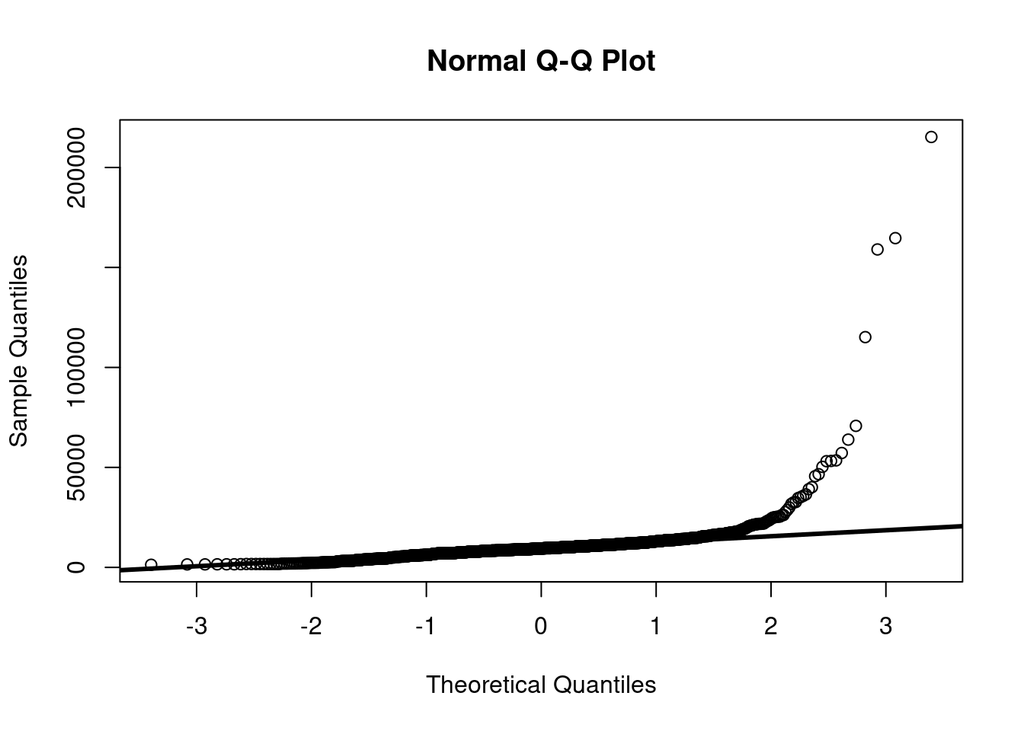

```r
## Por inspección visual se examina la normalidad de las variables contempladas
if (!require('ggplot2')) install.packages('ggplot2', dependencies = TRUE); library('ggplot2')
qqnorm(df_train$LotArea, pch = 1); qqline(df_train$LotArea, lwd = 3)
```

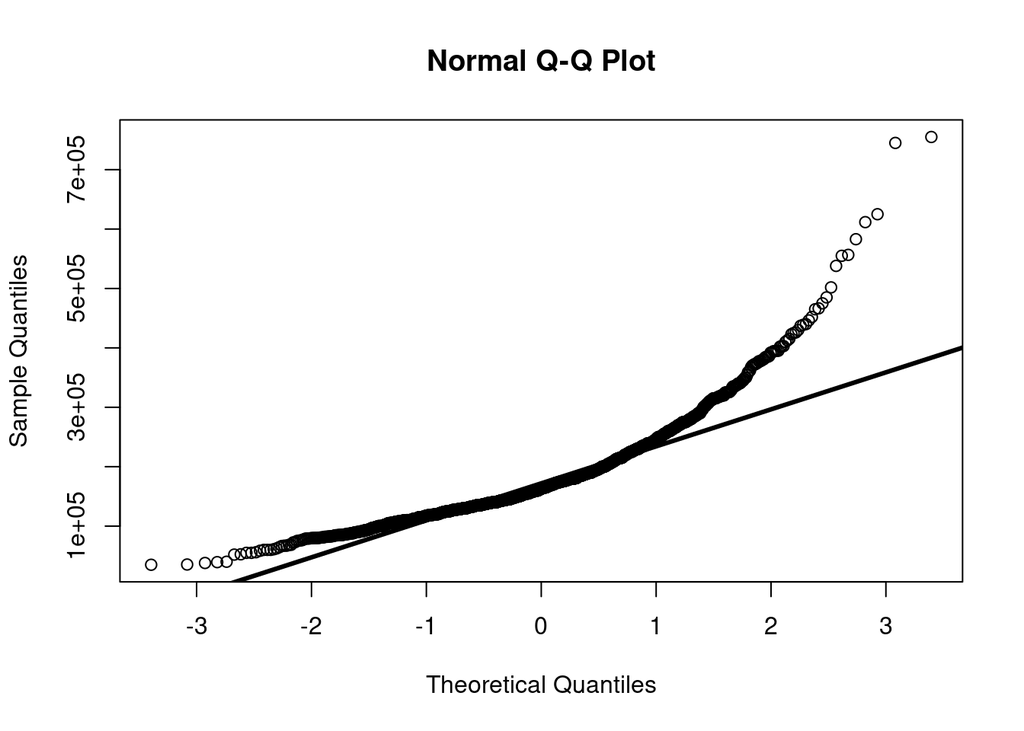

```r
qqnorm(df_train$SalePrice, pch = 1); qqline(df_train$SalePrice, lwd = 3)
```

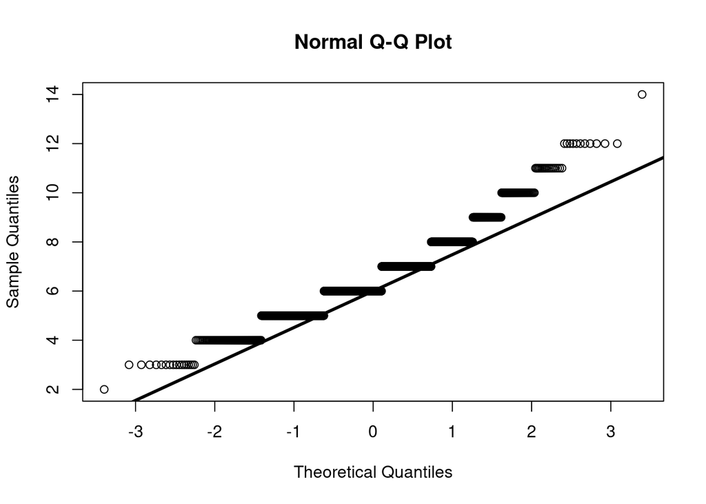

```r
qqnorm(df_train$TotRmsAbvGrd, pch = 1); qqline(df_train$TotRmsAbvGrd, lwd = 3)
```

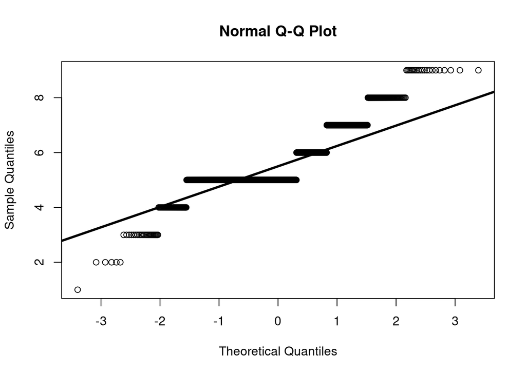

```r
qqnorm(df_train$OverallCond, pch = 1); qqline(df_train$OverallCond, lwd = 3)
```

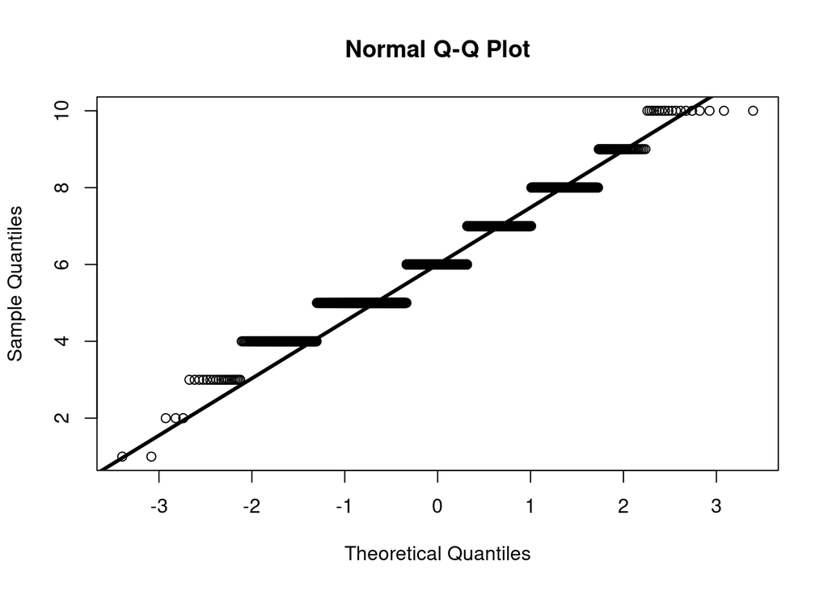

```r
qqnorm(df_train$OverallQual, pch = 1); qqline(df_train$OverallQual, lwd = 3)
```

```r
## Se aplica test estadístico para verificar la normalidad de las variables contempladas
if (!require('nortest')) install.packages('nortest', dependencies = TRUE); library('nortest')
lillie.test(df_train$LotArea)
```

```
##
##  Lilliefors (Kolmogorov-Smirnov) normality test
##
## data:  df_train$LotArea
## D = 0.25152, p-value < 2.2e-16
```

```r
lillie.test(df_train$SalePrice)
```

```
##
##  Lilliefors (Kolmogorov-Smirnov) normality test
##
## data:  df_train$SalePrice
## D = 0.12369, p-value < 2.2e-16
```

```r
lillie.test(df_train$TotRmsAbvGrd)
```

```
##
##  Lilliefors (Kolmogorov-Smirnov) normality test
##
## data:  df_train$TotRmsAbvGrd
## D = 0.16744, p-value < 2.2e-16
```

```r
lillie.test(df_train$OverallCond)
```

```
##
##  Lilliefors (Kolmogorov-Smirnov) normality test
##
## data:  df_train$OverallCond
## D = 0.32003, p-value < 2.2e-16
```

```r
lillie.test(df_train$OverallQual)
```

```
##
##  Lilliefors (Kolmogorov-Smirnov) normality test
##
## data:  df_train$OverallQual
## D = 0.15515, p-value < 2.2e-16
```

```r
# Ahora se comprueba homocedasticidad de la varianza para los grupos de datos que se analizarán bajo contraste de hipótesis
## Se generan los dos grupos para el contrase de hipótesis 1 (posteriormente se indicarán las ecuaciones de la hipótesis respectiva)
df_train_Neighborhood_CollgCr <- subset(df_train, df_train$Neighborhood == "CollgCr")
df_train_Neighborhood_BrkSide <- subset(df_train, df_train$Neighborhood == "BrkSide")

## Una vez verificado la distribución normal de los datos de aplica el f-test para comprobar su homocedasticidad
var.test(df_train_Neighborhood_CollgCr$LotArea, df_train_Neighborhood_BrkSide$LotArea)
```

```
##
##  F test to compare two variances
##
## data:  df_train_Neighborhood_CollgCr$LotArea and df_train_Neighborhood_BrkSide$LotArea
## F = 0.74622, num df = 149, denom df = 57, p-value = 0.1658
## alternative hypothesis: true ratio of variances is not equal to 1
## 95 percent confidence interval:
##  0.4727468 1.1286745
## sample estimates:
## ratio of variances
##          0.7462208
```

El p value es superior a 0.05, se concluye que la diferencia de las varianzas no es significativa. Se cumple el criterio de homocedasticidad

## 1.4 Aplicación de pruebas estadísticas para comparar los grupos de datos. En función de los datos y el objetivo del estudio, aplicar pruebas de contraste de hipótesis, correlaciones, regresiones, etc. Aplicar al menos tres métodos de análisis diferentes.

### 1.4.1 Contraste de hipótesis

#### 1.4.1.1 ¿Se puede asumir que las casas del barrio CollgCr tienen un mayor lote de área que las de BrkSide?

Las hipótesis son:

- H0: U1 - U2 = 0
- H1: U1 - U2 > 0

Se aplicará contraste de dos muestras independientes con varianzas desconocidas:

- La hipótesis establece dos muestras: Barrio CollgCr y Barrio BrkSide
- Las muestras son independientes dado que no existe una relación explícita entre ellas
- No se conoce la varianza de las poblaciones. En el pasó anterior se aplicó el test de igualdad de varianzas y se concluyó que la diferencia de varianzas no es significativa
- Unilateral a la derecha
- Ambas muestras superan las 30 observaciones

```r
### Se ejecuta el contraste unilateral por la derecha ("greater"), con varianzas iguales (var.equal = T) y se verifica
result <- t.test(df_train_Neighborhood_CollgCr$LotArea, df_train_Neighborhood_BrkSide$LotArea, alternative = "g", var.equal = T)
result; result$p.value
```

```
##
##  Two Sample t-test
##
## data:  df_train_Neighborhood_CollgCr$LotArea and df_train_Neighborhood_BrkSide$LotArea
## t = 5.9561, df = 206, p-value = 5.508e-09
## alternative hypothesis: true difference in means is greater than 0
## 95 percent confidence interval:
##  1632.138      Inf
## sample estimates:
## mean of x mean of y
##  9619.147  7360.414
```

```
## [1] 5.507853e-09
```

#### 1.4.1.2 ¿La varianza del precio de venta es diferente de 70442^2??

Se aplicará contraste sobre la varianza:

```r
### Se ejecuta el test de igualdad de varianzas con sigma elevado a 2
if (!require('EnvStats')) install.packages('EnvStats', dependencies = TRUE); library('EnvStats')
varTest(df_train$SalePrice, alternative = "two.sided", sigma.squared = 4962075364, conf.level = 0.95, data.name = NULL)
```

```
##
##  Chi-Squared Test on Variance
##
## data:  df_train$SalePrice
## Chi-Squared = 1855.7, df = 1459, p-value = 1.213e-11
## alternative hypothesis: true variance is not equal to 4962075364
## 95 percent confidence interval:
##  5877056096 6795343509
## sample estimates:
##   variance
## 6311111264
```

### 1.4.2 Correlación de variables

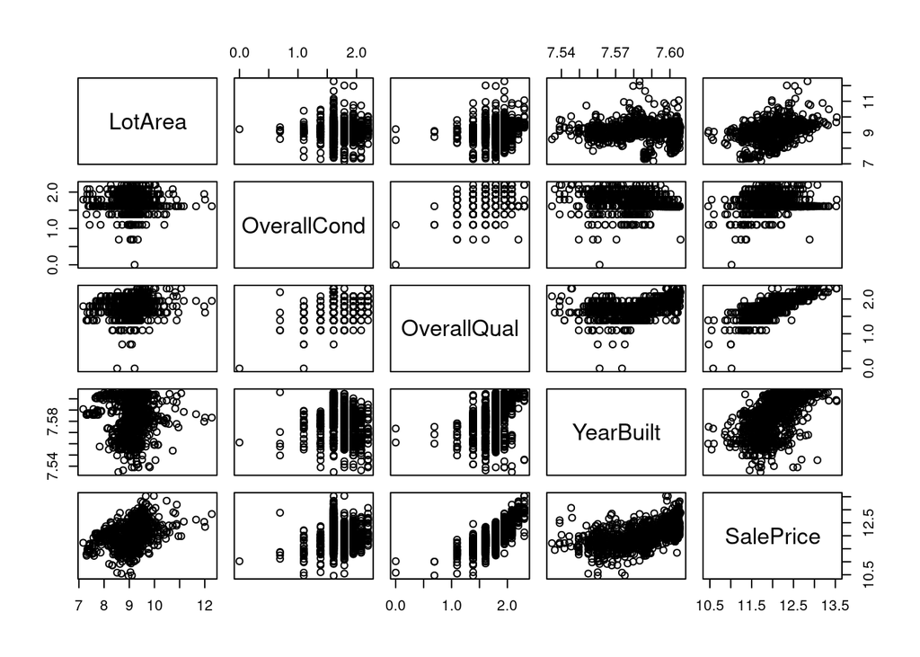

```r
### Se aplicará Pearson para variables lineales y numéricas. Posteriormente se usará chi-cuadrado para las variables categóricas
### Dada la poca normalidad de los datos se convertirán a escala logarítmica con el propósito de mejorar la inspección visual. Se seleccionan solamente las variables numéricas de ínteres
if (!require('dplyr')) install.packages('dplyr', dependencies = TRUE); library('dplyr')
df_train.log <- log(select(df_train, c(LotArea, OverallCond, OverallQual, YearBuilt, SalePrice)))
### Se generan los gráficos de dispersión por cada variable de ínteres.
if (!require('dplyr')) install.packages('dplyr', dependencies = TRUE); library('dplyr')
pairs(df_train.log)
```

```r
### Se calcula el grado de correlación lineal de las variables de ínteres con Pearson, dado que los datos siguen una distribución normal y cumplen con el criterio de homocedasticidad
cor(df_train.log, method = "pearson")
```

```
##                  LotArea  OverallCond OverallQual   YearBuilt   SalePrice
## LotArea      1.000000000 -0.004773907  0.16292474  0.02221499 0.399917741
## OverallCond -0.004773907  1.000000000  0.02478469 -0.30391925 0.008709675
## OverallQual  0.162924740  0.024784690  1.00000000  0.55343058 0.794007493
## YearBuilt    0.022214995 -0.303919255  0.55343058  1.00000000 0.584442329
## SalePrice    0.399917741  0.008709675  0.79400749  0.58444233 1.000000000
```

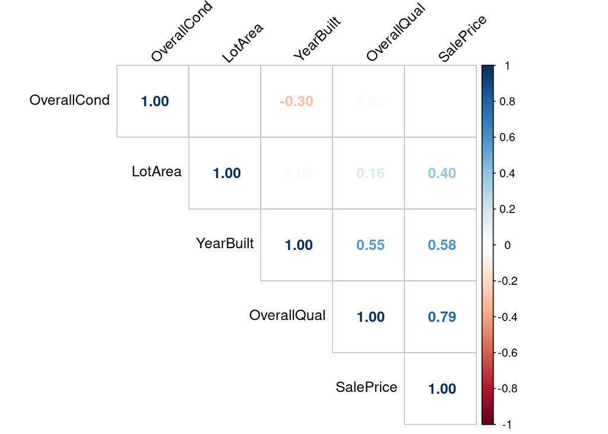

[output not shown]

```r
### Se visualiza gráficamente las relaciones entre las variables
if (!require('corrplot')) install.packages('corrplot', dependencies = TRUE); library('corrplot')
corrplot(cor(df_train.log, method = "pearson"), method = "number", type = "upper", order = "hclust", tl.col = "black", tl.srt = 45)
```

```r
### Se aplica chi-cuadrado para las variables categóricas
### Se discretiza el precio de venta y condición general usando k-means (3 grupos)
if (!require('arules')) install.packages('arules', dependencies = TRUE); library('arules')

df_train$SalePrice_cat <- discretize(df_train$SalePrice, method = "cluster",
              breaks = 3,
              labels = c("LowPrice", "MidPrice", "HighPrice"))
df_train$OverallCond_cat <- discretize(df_train$OverallCond, method = "cluster",
              breaks = 3,
              labels = c("BadConditions", "AcceptableConditions", "VeryGoodConditions"))

contigency_OverallCond_catVsSalePrice_cat <- table(df_train$SalePrice_cat, df_train$OverallCond_cat); contigency_OverallCond_catVsSalePrice_cat
```

```
##
##             BadConditions AcceptableConditions VeryGoodConditions
##   LowPrice             82                  509                210
##   MidPrice              5                  458                 77
##   HighPrice             1                  106                 12
```

```r
chisq <- chisq.test(contigency_OverallCond_catVsSalePrice_cat); chisq
```

```
##
##  Pearson's Chi-squared test
##
## data:  contigency_OverallCond_catVsSalePrice_cat
## X-squared = 105.67, df = 4, p-value < 2.2e-16
```

```r
round(chisq$p.value)
```

```
## [1] 0
```

Con un p-value menor a 0.05, se puede establecer que existe una relación significativa entre el precio de venta categorizado y la condicion general de la casa categorizada

```r
### A partir de la tabla de contingencia generada se obtendrán los porcentajes y su interpretación
contigency_OverallCond_catVsSalePrice_cat.perc <- prop.table(contigency_OverallCond_catVsSalePrice_cat, margin = 2) * 100; contigency_OverallCond_catVsSalePrice_cat.perc
```

```
##
##             BadConditions AcceptableConditions VeryGoodConditions
##   LowPrice      93.181818            47.437092          70.234114
##   MidPrice       5.681818            42.684063          25.752508
##   HighPrice      1.136364             9.878844           4.013378
```

- Cuando las condiciones son malas, el 93.18% de las casas en venta tienen un precio bajo
- Cuando las condiciones son malas, el 5.68% de las casas en venta tienen un precio medio
- Cuando las condiciones son malas, el 1.13% de las casas en venta tienen un precio alto
- Cuando las condiciones son aceptables, el 47.43% de las casas en venta tienen un precio bajo
- Cuando las condiciones son aceptables, el 42.68% de las casas en venta tienen un precio medio
- Cuando las condiciones son aceptables, el 9.87% de las casas en venta tienen un precio alto
- Cuando las condiciones son buenas, el 70.23% de las casas en venta tienen un precio bajo
- Cuando las condiciones son buenas, el 25.75% de las casas en venta tienen un precio medio
- Cuando las condiciones son buenas, el 4.01% de las casas en venta tienen un precio alto

### 1.4.3 Regresión lineal múltiple

Se debe examinar si existe o no colinealidad entre las variables regresoras del modelo. Para esto se calculará el factor de inflación de la varianza (FIV)

```r
### Se genera el modelo de regresión lineal múltiple
salePrice_multiple_regression <- lm(SalePrice ~ LotArea + OverallCond + OverallQual + YearBuilt, data = df_train.log)
### Se imprimen los resultados para análisis
summary(salePrice_multiple_regression)
```

```
##
## Call:
## lm(formula = SalePrice ~ LotArea + OverallCond + OverallQual +
##     YearBuilt, data = df_train.log)
##
## Residuals:
##      Min       1Q   Median       3Q      Max
## -1.11969 -0.11613 -0.01436  0.11385  1.15896
##
## Coefficients:
##              Estimate Std. Error t value Pr(>|t|)
## (Intercept) -46.06603    3.36571 -13.687  < 2e-16 ***
## LotArea       0.22989    0.01030  22.313  < 2e-16 ***
## OverallCond   0.15572    0.02805   5.551 3.36e-08 ***
## OverallQual   0.97932    0.02733  35.829  < 2e-16 ***
## YearBuilt     7.11639    0.44369  16.039  < 2e-16 ***
## ---
## Signif. codes:  0 '***' 0.001 '**' 0.01 '*' 0.05 '.' 0.1 ' ' 1
##
## Residual standard error: 0.2 on 1455 degrees of freedom
## Multiple R-squared:  0.7499, Adjusted R-squared:  0.7492
## F-statistic:  1091 on 4 and 1455 DF,  p-value: < 2.2e-16
```

```r
### Se calcula el factor de inflación de la varianza (FIV)
if (!require('faraway')) install.packages('faraway', dependencies = TRUE); library('faraway')
vif(salePrice_multiple_regression)
```

```
##     LotArea OverallCond OverallQual   YearBuilt
##    1.036342    1.173297    1.587030    1.701788
```

El FIV arroja un valor inferior a 5 para todas las variables regresoras. Se puede argumentar que no existe colinealidad, por tanto, se incluyen todas las variables regresoras en el modelo

Al examinar el modelo de regresión se obtiene:

- El coeficiente R2 arroja un valor de 0.7499. La calidad de la recta de regresión y del modelo son buenas

Ahora se examinan los residuos como criterio de validación del modelo

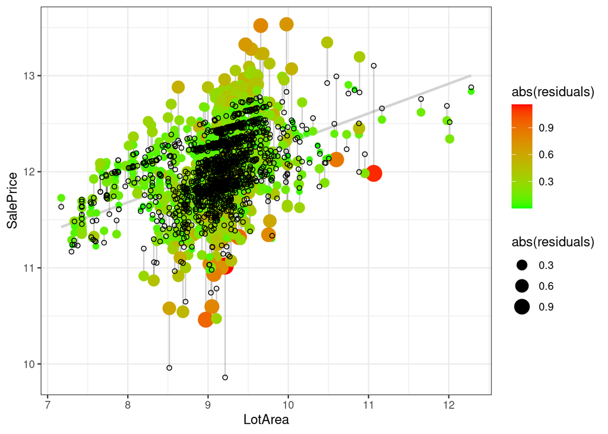

```r
### Se extraen y guardan los valores residuales y ajustados
df_train.log$predicted <- predict(salePrice_multiple_regression)
df_train.log$residuals <- residuals(salePrice_multiple_regression)

### Se pinta gráfica y se destacan los valores residuales
ggplot(df_train.log, aes(x = LotArea, y = SalePrice)) +
  geom_smooth(method = "lm", se = FALSE, color = "lightgrey") +
  geom_segment(aes(xend = LotArea, yend = predicted), alpha = .2) +
  geom_point(aes(color = abs(residuals), size = abs(residuals))) +
  scale_color_continuous(low = "green", high = "red") +
  geom_point(aes(y = predicted), shape = 1) +
  theme_bw()
```

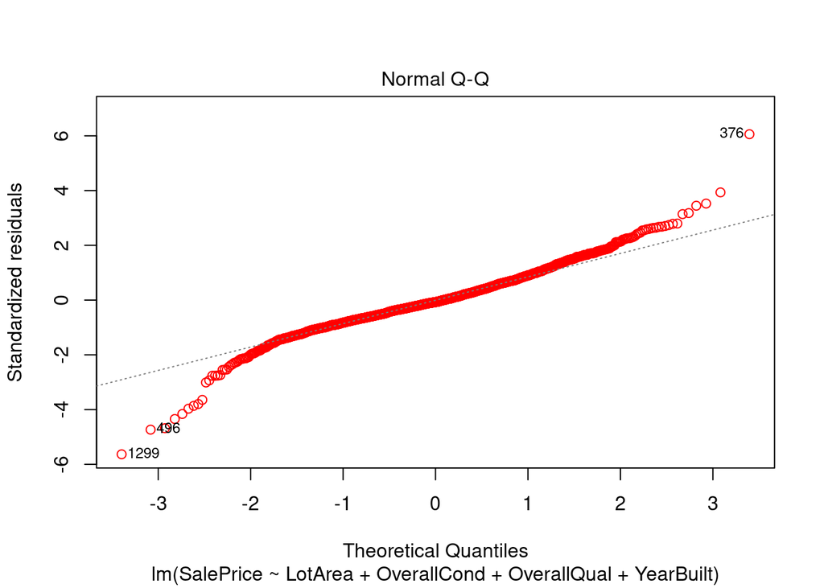

```r
plot(salePrice_multiple_regression, which = 2, col = c("red"))  # Q-Q Plot
```

Se evidencian varios datos atípicos que pueden ser tratados para mejorar la calidad del modelo. No obstante, el conjunto de puntos impresos en el gráfico no muestran ningún tipo de estructura, lo que confirma, parcialmente, el correcto ajuste del modelo a los datos.

Ahora se hará una predicción según el modelo generado con valores explícitos de las variables regresoras

```r
lotArea <- log(8650)
overallCond <- log(6)
overallQual <- log(5)
yearBuilt <- log(2004)

## Se construye la recta de regresión y se aplican los valores para la predicción
salePrice_prediction <- -46.0660 +
  (lotArea * 0.2298) +
  (overallCond * 0.1557) +
  (overallQual * 0.9793) +
  (yearBuilt * 7.1163); exp(salePrice_prediction)
```

```
## [1] 159027
```

Dado un lote con área de 8650, condición general de 6, calidad general de 5 y año de construcción 2004, su precio es de 159027

## 1.5 Resumen ejecutivo

- R ya nos ofrece funciones built-in para efectuar contraste de hipótesis, incluyendo unilaterildad o bilaterilidad, el valor observado y la consideración si la varianza poblacional es igual o no. Ofrece también funciones para geberar modelos de regresión lineal y regresión logística
- Los cálculos manuales requieren comprender muy bien la distribución normal y t student para poder ubicar bien los quartiles, las colas y el valor observado.
- Se debe examinar la naturaleza (dicotómica, politómica, continua) de la variable dependiente e independientes para determinar que método de regresión usar y su respectiva comprobación de ajuste
- El teorema del límite central es el punto de partida para el cálculo de intervalos de confianza y contraste de hipótesis. Resulta necesaria el descarte o aplicación del teorema para determinar el tipo de distribución de las medias muestrales y el test a aplicar
- Determinar la relación entre variables para la aplicación de un contraste de hipótesis es necesario para determinar si aplicar un test de variables independientes o un test de variables dependientes
- Conocer o no las varianzas poblacionales, y su igualdad o diferencia (homo/heteroscedasticidad), determinará el test a aplicar y la distribución a seguir
- El contraste de hipótesis no solo aplica a medidas de tendencia central como la media, sino también a medidas de dispersión como la varianza. La medida de proporción también es aplicable en un contraste de hipótesis
- El gráfico QQ y la función lilliefors resultan útiles para comprobar la distribución de una muestra
- La conversión a escala logarítmica de una característica de una muestra es muy útil para aplicar análisis por inspección visual
- P-value permite determinar, en función de otros datos, considerar el rechazo o no de la hipótesis nula